# Assignment4

2023-10-25

## Assignment 4 - Linear Regression

#### Scenario 1 - Blood pressure vs coffee consumption

- Load tidyverse library

```r
library(tidyverse)
```

- Some preliminary data cleaning should be done in Excel before loading, namely:
  - Rename the column labeled ‘Cups of Coffee’ to ‘Cups’
  - Rename the column labeled ‘Blood Pressure (Systolic Pressure)’ to ‘BP’
- Load coffee_bloodPressure csv file

```r
df_coffee <- read.csv("coffee_bloodPressure.csv")
```

- Examining the data shows no missing values or need for additional data cleaning.
1. Find the correlation between coffee consumption and blood pressure using the scatter plot

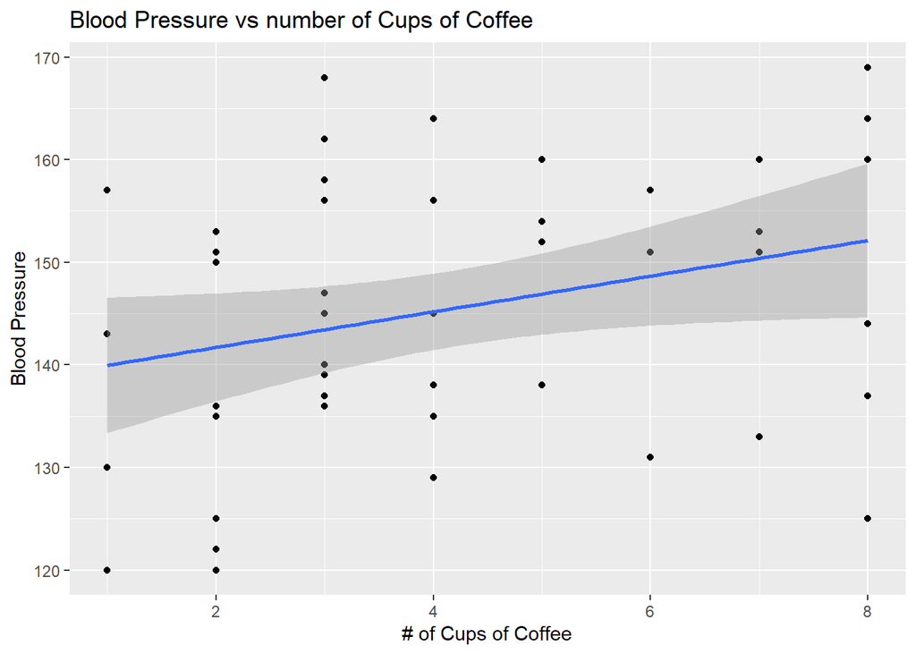

```r
df_coffee %>%
  ggplot(aes(Cups, BP)) +
  geom_point() +
  geom_smooth(method="lm") +
  labs(title = "Blood Pressure vs number of Cups of Coffee",
       x = "# of Cups of Coffee",
       y = "Blood Pressure")
```

2. Describe the relationship between coffee consumption and blood pressure and explain what someone should do if their doctor says that their blood pressure is a concern.
- The graph shows a positive correlation between blood pressure and number of cups of coffee consumed. The confidence that can be placed in this relationship will be assessed as part of the linear regression model created in step 2.
- Perhaps more significantly many of the participants have elevated blood pressure. Many of the observations are in hypertension stage 1 (130 - 139) or stage 2 (140 or higher). (Source: [Healthy and Unhealthy Blood Pressure Ranges](https://www.heart.org/en/health-topics/high-blood-pressure/understanding-blood-pressure-readings))
- Reducing the coffee they consume seems prudent under these circumstances, but they should also consult with their doctor if other interventions are advised.
3. Train the model and predict the values for 8 and 6 cups of coffee in a day.
- This will be accomplished by creating a linear regression model between blood pressure and number of cups of coffee for the observations and drawing conclusions on the robustness of the model and its predictions.
- Initialize random number generator for reproducibility

  ```r
  set.seed(1)
  ```

- Create ID column

  ```r
  df_coffee$id <- 1:nrow(df_coffee)
  ```

- Split the dataset into training and testing portions, using 80% as training and 20% as test set.

  ```r
  # dataframe_new <- actual_dataframe %>% sample_frac(value)
  train_coffee <- df_coffee %>% sample_frac(0.80)

  # dataframe_new <- anti_join(actual_dataframe,
  #                            training_dataframe,
  #                            by = 'column')
  test_coffee <- anti_join(df_coffee, train_coffee, by = "id")
  ```

- Create linear regression model of blood pressure vs cups of coffee consumed using training data

  ```r
  coffee_model <- lm(BP ~ Cups, data=train_coffee)
  ```

- Display properties of linear regression model

  ```r
  summary(coffee_model)
  ```

  ```
  ##
  ## Call:
  ## lm(formula = BP ~ Cups, data = train_coffee)
  ##
  ## Residuals:
  ##     Min      1Q  Median      3Q     Max
  ## -27.211  -8.794   1.894   9.956  19.965
  ##
  ## Coefficients:
  ##             Estimate Std. Error t value Pr(>|t|)
  ## (Intercept) 135.9300     4.6324  29.343   <2e-16 ***
  ## Cups          2.0352     0.9732   2.091   0.0436 *
  ## ---
  ## Signif. codes:  0 '***' 0.001 '**' 0.01 '*' 0.05 '.' 0.1 ' ' 1
  ##
  ## Residual standard error: 13.02 on 36 degrees of freedom
  ## Multiple R-squared:  0.1083, Adjusted R-squared:  0.08355
  ## F-statistic: 4.373 on 1 and 36 DF,  p-value: 0.04363
  ```

- Create predictions using test data from split dataset

  ```r
  test_coffee$predictions <- predict(coffee_model, test_coffee)
  ```

- Graph predicted vs actual values of test data

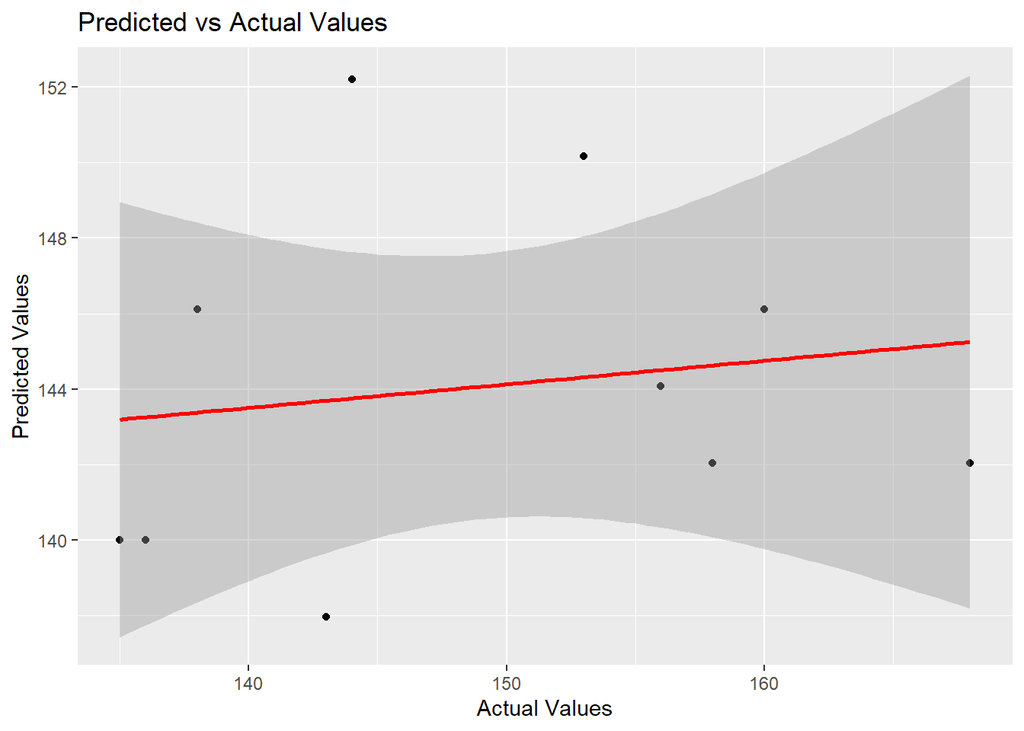

```r
test_coffee %>%
  ggplot(aes(x = BP, y = predictions)) +
  geom_point() +
  geom_smooth(method=lm, color="red") +
  labs(x = "Actual Values", y = "Predicted Values",
       title = "Predicted vs Actual Values")
```

- Predict the blood pressure reading following 8 cups of coffee.

  ```r
  new_data <- data.frame(Cups = 8)
  predict(coffee_model, new_data)
  ```

  ```
  ##        1
  ## 152.2113
  ```

- The predicted blood pressure following 8 cups of coffee is 152.
- Predict the blood pressure reading following 6 cups of coffee.

  ```r
  new_data <- data.frame(Cups = 6)
  predict(coffee_model, new_data)
  ```

  ```
  ##        1
  ## 148.1409
  ```

#### Scenario 2 - Dental income vs price

- Some preliminary data cleaning should be done in Excel before loading, namely:
  - Rename the column labeled ‘Income(K)’ to ‘Income’
  - Rename the column labeled ‘Dentist (# of Visits)’ to ‘Visits.’ This column won’t be used in the current analysis.
  - Remove space in front of ‘Price’ column heading
- Load dentalServices.csv file

```r
# read csv
df_dental <- read.csv("dentalService.csv")
```

1. Create scatter plot of income vs price

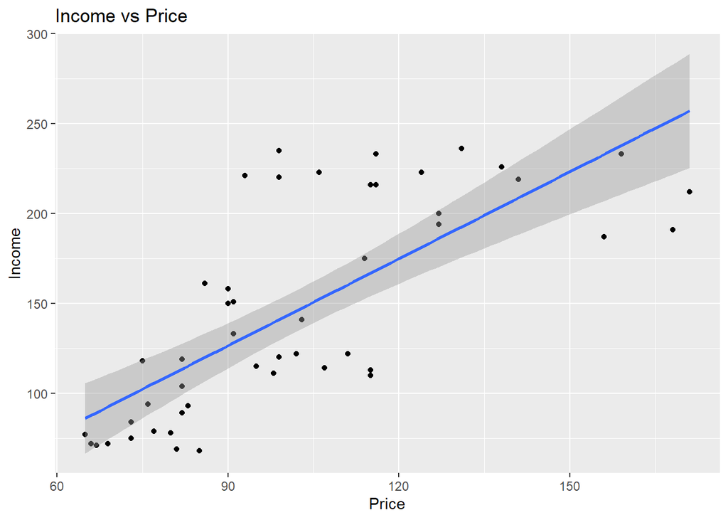

```r
df_dental %>%
  ggplot(aes(Price, Income)) +
  geom_point() +
  geom_smooth(method="lm") +
  labs(title = "Income vs Price",
       x = "Price",
       y = "Income")
```

2. Analyze the data and add a regression line
- Initialize random number generator for reproducibility

  ```r
  set.seed(1)
  ```

- Create ID column

  ```r
  df_dental$id <- 1:nrow(df_dental)
  ```

- Split the dataset into training and testing portions, using 80% as training and 20% as test set.

  ```r
  # dataframe_new <- actual_dataframe %>% sample_frac(value)
  train_dental <- df_dental %>% sample_frac(0.80)

  # dataframe_new <- anti_join(actual_dataframe, training_dataframe, by = 'column')
  test_dental <- anti_join(df_dental, train_dental, by = "id")
  ```

- Create linear regression model of income vs price charged for dental services

  ```r
  dental_model <- lm(Income ~ Price, data=train_dental)
  ```

- Display properties of linear regression model

  ```r
  summary(dental_model)
  ```

  ```
  ##
  ## Call:
  ## lm(formula = Income ~ Price, data = train_dental)
  ##
  ## Residuals:
  ##    Min     1Q Median     3Q    Max
  ## -56.47 -25.47 -11.64  21.83  88.50
  ##
  ## Coefficients:
  ##             Estimate Std. Error t value Pr(>|t|)
  ## (Intercept) -10.0497    23.7259  -0.424    0.674
  ## Price         1.5329     0.2236   6.854 4.44e-08 ***
  ## ---
  ## Signif. codes:  0 '***' 0.001 '**' 0.01 '*' 0.05 '.' 0.1 ' ' 1
  ##
  ## Residual standard error: 37.73 on 37 degrees of freedom
  ## Multiple R-squared:  0.5594, Adjusted R-squared:  0.5475
  ## F-statistic: 46.98 on 1 and 37 DF,  p-value: 4.441e-08
  ```

- Create predictions using test data from split dataset

  ```r
  test_dental$predictions <- predict(dental_model, test_dental)
  ```

Graph predicted vs actual values of test data

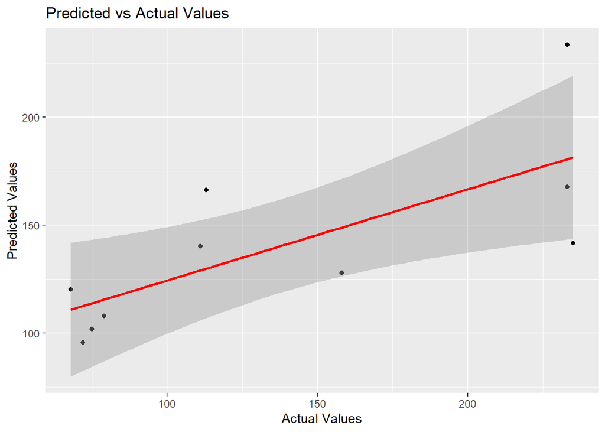

```r
test_dental %>%
  ggplot(aes(x = Income, y = predictions)) +
  geom_point() +
  geom_smooth(method=lm, color="red") +
  labs(x = "Actual Values", y = "Predicted Values",
       title = "Predicted vs Actual Values")
```

3. Predict the next two price points ($200 and $50)
- Predict the income produced at a $200 price point.

```r
new_data <- data.frame(Price = 200)
predict(dental_model, new_data)
```

```
##        1
## 296.5206
```

- The predicted income at a $200 price point is $296,521.
- Predict the income at a $50 price point.

  ```r
  new_data <- data.frame(Price = 50)
  predict(dental_model, new_data)
  ```

  ```
  ##        1
  ## 66.59287
  ```

- The predicted income at a $50 price point is $66,593.
4. Add both new values to the scatter linear graph.
- Create new row with income prediction at $200 price.

  ```r
  new_row <- data.frame(
    Income = 296.5206,
    Visits = 10,
    Price = 200,
    id = 50
  )
  ```

- Create new row with income prediction at $50 price.

  ```r
  new_row2 <- data.frame(
    Income = 66.59287,
    Visits = 10,
    Price = 50,
    id = 51
  )
  ```

  ```r
  df_dental_revised <- rbind(df_dental, new_row)
  df_dental_revised <- rbind(df_dental_revised, new_row2)
  ```

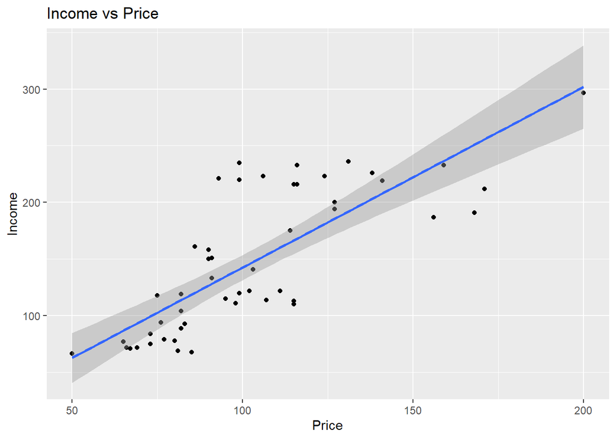

  ```r
  df_dental_revised %>%
    ggplot(aes(Price, Income)) +
    geom_point() +
    geom_smooth(method="lm") +
    labs(title = "Income vs Price",
         x = "Price",
         y = "Income")
  ```